# Project 1: Wrangling, Exploration, Visualization

SDS322E

## Data Wrangling, Exploration, Visualization

### Emily Dunnahoe ekd489

#### Introduction

Is bigfoot an alien? This is the riveting question that this wrangling, exploring, and visualizing activity is not going to answer. I will look at paranormal sightings across the US, according to “paratype”, and season of sighting. I will consider the longitudes, latitudes, seasons, and states to eke out any possible meaning. Mostly, I hope to be entertained.

```r
UFO_sightings <- read.csv("https://query.data.world/s/kt4hdqddosnopecjgfcm2j3qk3ixek",
    header = TRUE, stringsAsFactors = FALSE)
big_foot <- read.csv("https://query.data.world/s/72wj67foxle6ztzeirnbdz6kpomzag",
    header = TRUE, stringsAsFactors = FALSE)
```

#### Tidying: Reshaping

My data was already tidy. So, below is really just arbitrary pivoting. Due of the number of variables present, I paired everything done is in the joining/merging section below to make reshaping feel more reasonable from my perspective.

```r
library(tidyverse)
big_foot <- big_foot %>% pivot_wider(names_from = "classification",
    values_from = "number")
big_foot <- big_foot %>% pivot_longer(27:29, names_to = "classification",
    values_to = "number")

library(tidyverse)
big_foot_clean <- big_foot %>% select(-c(2, 5, 6, 10:28)) %>%
    add_column(paratype = "bigfoot")
big_foot_clean <- big_foot_clean %>% na.omit() %>% slice(1:500)

UFO_sightings_clean <- UFO_sightings %>% separate("date_time",
    into = c("date", "NA"), sep = "T")

longitude <- as.numeric(as.character(UFO_sightings_clean$city_longitude))
latitude <- as.numeric(as.character(UFO_sightings_clean$city_latitude))
UFO_sightings_clean <- UFO_sightings_clean %>% add_column(paratype = "UFO") %>%
    select(-c(5:11)) %>% na.omit() %>% slice(1:500)
```

#### Joining/Merging

```r
bf_clean <- big_foot %>% select(-c(2, 3, 5, 6, 10:28)) %>% add_column(paratype = "bigfoot") %>%
    na.omit() %>% slice(1:500)
bf_clean <- bf_clean %>% group_by(state) %>% mutate(ID = cur_group_id())

UFO_clean <- UFO_sightings %>% separate("date_time", into = c("date",
    "NA"), sep = "T")
longitude <- as.numeric(as.character(UFO_clean$city_longitude))
latitude <- as.numeric(as.character(UFO_clean$city_latitude))
UFO_clean <- UFO_clean %>% add_column(paratype = "UFO") %>% na.omit() %>%
    slice(1:500) %>% select(-c(5:11))
UFO_clean <- UFO_clean %>% group_by(state) %>% mutate(ID = cur_group_id())

big_clean_UFO <- bf_clean %>% full_join(UFO_clean, by = c(latitude = "city_latitude",
    longitude = "city_longitude", state = "state", paratype = "paratype",
    date = "date", observed = "summary", ID = "ID"))
```

Due to peculiarities of my data or my level of expertise, I had to alter both data sets a bit to get a join that made sense. Above is all of the cleaning steps that happened before joining and my performative reshaping above.

#### Wrangling

```r
library(lubridate)
date_new <- as.Date(paste(big_clean_UFO$date, "-01", sep = ""))
big_clean_UFO <- big_clean_UFO %>% mutate(season = lubridate::quarter(date)) %>%
    mutate(season = case_when(season == 1 ~ "Winter", season ==
        2 ~ "Spring", season == 3 ~ "Summer", season == 4 ~ "Fall")) %>%
    separate(date, into = c("year", "month", "day")) %>% select(-c("year",
    "day", "city"))
big_clean_UFO %>% group_by(state, season, paratype) %>% summarise(mean_lo = mean(longitude),
    sd_lo = sd(longitude), mean_la = mean(latitude), sd_la = sd(latitude),
    var_lola = var(longitude, latitude, na.rm = T), max_lo = max(longitude),
    max_la = max(latitude), min_lo = min(longitude), min_la = min(latitude))
```

```
## # A tibble: 168 x 12
## # Groups:   state, season [168]
##    state season paratype mean_lo   sd_lo mean_la   sd_la var_lola max_lo max_la
##    <chr> <chr>  <chr>      <dbl>   <dbl>   <dbl>   <dbl>    <dbl>  <dbl>  <dbl>
##  1 AB    Summer UFO       -114.   0.513     53.2  3.00   -1.54    -114.    55.3
##  2 AK    Winter UFO       -149.   0.0553    60.6  0.820   0.0453  -149.    61.2
##  3 AL    Fall   UFO        -86.8 NA         33.5 NA      NA        -86.8   33.5
##  4 AL    Spring UFO        -86.6  0.821     32.9  1.16    0.225    -85.1   34.0
##  5 AL    Winter UFO        -88.2  0.151     31.2  0.733   0.0872   -87.9   32.4
##  6 AR    Spring UFO        -93.4  1.51      36.0  0.0811 -0.122    -90.7   36.0
##  7 AR    Summer UFO        -94.3 NA         35.9 NA      NA        -94.3   35.9
##  8 AR    Winter UFO        -93.6  0.696     35.6  0.583  -0.406    -93.1   36.0
##  9 AZ    Fall   UFO       -112.   0.0988    33.4  0.0526 -0.00520 -112.    33.4
## 10 AZ    Spring UFO       -112.   1.18      33.5  0.963  -1.08    -111.    35.1
## # … with 158 more rows, and 2 more variables: min_lo <dbl>, min_la <dbl>
```

```r
tired <- big_clean_UFO %>% group_by(state, ID, paratype, season) %>%
    summarise(n = n()) %>% arrange(desc(n))

big_clean_UFO %>% filter(season == "Winter") %>% stringr::str_count("cold")
```

```
## [1] 9 0 0 0 0 0 0 0
```

To better understand circumstances when and where paranormal sightings generally occur, I created a seasons column using mutate(), before removing the year/day/city using separate() and select(). I grouped by paratype, state, and season before generating summary statistic for longitude, latitude. Unfortunately, this information wasn’t vary enlightening in isolation.

The next chunk was an attempt to contextualize previous numeric summary using the season, state, and paratype character variable in the cleaned data. After using trusty group_by() for state and ID I summarized the number sighting occured in each state, before arranging the results in descending order.

My last chunck was really just a points grab. I filtered rows by season (winter) and then used str_count to determine how many times observations contained the word “cold”. Nine times, which is clearly suspicious.

#### Visualizing

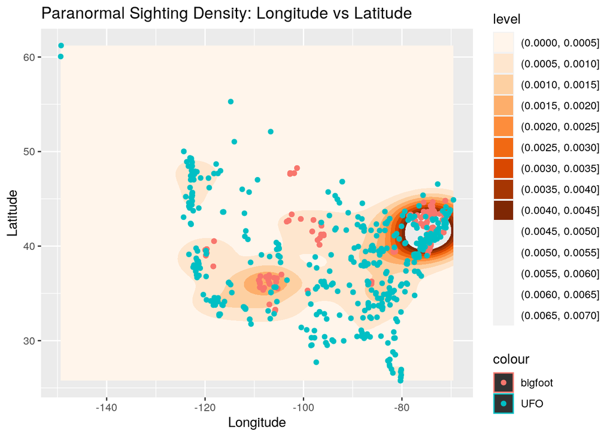

```r
library(RColorBrewer)
ggplot(big_clean_UFO, aes(longitude, latitude)) + geom_density2d_filled() +
    geom_jitter(aes(colour = paratype)) + scale_fill_brewer(palette = "Oranges") +
    labs(title = "Paranormal Sighting Density: Longitude vs Latitude",
        x = "Longitude", y = "Latitude")
```

This plot considers the probability of of bigfoot and UFO sightings across differing latitudes and longitudes. Vaguely U.S. shaped, it is clear that there is a higher occurrence of bigfoot sightings in the northeast—specifically around Ohio, which is consistent with summary statistic collected in the Wrangling section. UFO sight are more widely dispersed. Behold, it’s beauty!

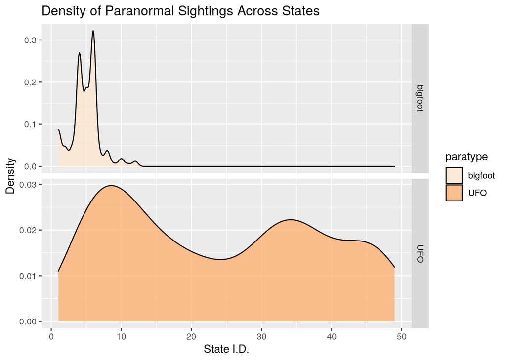

```r
library(RColorBrewer)

ggplot(big_clean_UFO, aes(x = ID, fill = paratype)) + geom_density(alpha = 0.75) +
    facet_grid(paratype ~ ., scales = "free_y") + scale_fill_brewer(palette = "Oranges") +
    labs(title = "Density of Paranormal Sightings Across States",
        x = "State I.D.", y = "Density")
```

This plot displays the density of sightings across states in accordance with numeric State I.D. assigned to the data. It is a closer view of the distribution of sightings, which reiterates the the conclusion from the first plot.

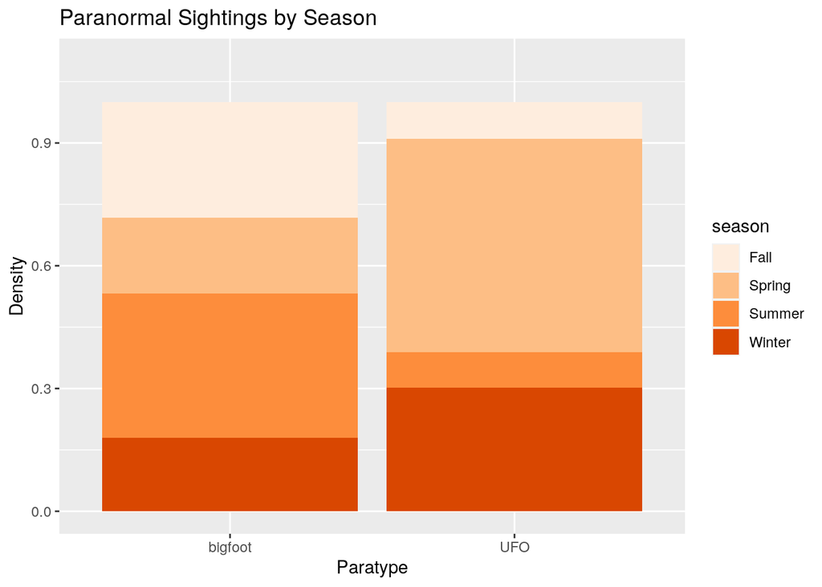

```r
library(RColorBrewer)
library(ggplot2)
ggplot(big_clean_UFO, aes(x = paratype, fill = season)) + geom_bar(position = "fill") +
    scale_fill_brewer(palette = "Oranges") + scale_y_continuous(name = "Density",
    limits = (c(0, 1.1))) + labs(title = "Paranormal Sightings by Season",
    x = "Paratype", y = "Density")
```

The final bar plot shows a breakdown of sightings according to season and paratype. Interestingly, there appears to be a seasonal fluctuation of UFO sighting according to season that is absent of the bigfoot folks.

#### Concluding Remarks

What is going on in Ohio?